# Bella_beat_2

Ameen

10/7/2021

# Fitness-Tracker-Analysis

## 1. Summary

#### This Project explores the Fitbit dataset, which entails of 33 users fitness data from April, 2016 to May, 2016. The aims of the analysis is to find the trends of a fitness tracker usage and recommend Bellabeat’s marketing team, who also happens to be a Stakeholder in this project. Using R, I analyze the trend of features usage, sleep and activity in which users are grouped into 4 groups based on daily intensity. Finally, recommendations for each group is provided at the end of the document, along with other suggestions.

## 2. Introduction

## Bellabeat

#### Bellabeat is a high-tech manufacturer of health-focused products for women. Collecting data on activity, sleep, stress, and reproductive health has allowed Bellabeat to empower women with knowledge about their own health and habits. Since it was founded in 2013, Bellabeat has grown rapidly and quickly positioned itself as a tech-driven wellness company for women.

## Business Task

#### Analyze smart device usage data in order to gain insight into how consumers use non-Bellabeat smart devices and provide high-level recommendation for Bellabeat’s marketing strategy. The main questions include:

- What are some trends in smart device usage?
- How could these trends apply to Bellabeat customers?
- How could these trends help influence Bellabeat marketing strategy?

## Framework

#### The data of this study is from Fitbit, a fitness smart device’s company. The data includes daily activity, sleep, heartrate and weight data.

#### As the aim of this project is to discover smart fitness devices user trends, The focus is on three main aspects as follows:

#### 1. User’s tendency to use different tracking features

#### 2. User’s activity and exercise trend

#### 3. User’s sleep pattern

## 3. Prepare data

### Fitabit dataset

#### These datasets were generated by respondents to a distributed survey via Amazon Mechanical Turk between 03/12/2016-05/12/2016. Thirty eligible Fitbit users consented to the usage of their personal tracker data, including minute-level output for physical activity, heart rate, and sleep monitoring. Individual reports can be parsed by export session ID (column A) or timestamp (column B). Variation between output represents use of different types of Fitbit trackers and individual tracking behaviors / preferences.

#### The explanation for each measurment in the dataset is present here: Link[Click here] (https://www.fitabase.com/media/1930/fitabasedatad)

```r
#Import data
daily_activity <- dailyActivity_merged
hourly_calories <- hourlyCalories_merged
hourly_intensities <- hourlyIntensities_merged
hourly_steps <- hourlySteps_merged
daily_sleep <- sleepDay_merged
weight <- weightLogInfo_merged
heartrate <- heartrate_seconds_merged
minute_sleep <- minuteSleep_merged
```

## 4. Process Data

```r
#Check missing values
sum(is.na(daily_activity)) #No missing value
## [1] 0
sum(is.na(hourly_calories)) #No missing value
## [1] 0
sum(is.na(hourly_intensities)) #No missing value
## [1] 0
sum(is.na(hourly_steps)) #No missing value
## [1] 0
sum(is.na(daily_sleep)) #No missing value
## [1] 0
sum(is.na(weight)) #65 missing values in the Fat columns
## [1] 65
```

#### Most users do not enter the Fat column. This is probably because most people do not want to measure or lack equipment to their fat on a regular basis.

```r
#Check for duplicates
sum(duplicated(daily_activity)) #No duplicates
## [1] 0
sum(duplicated(hourly_calories)) #No duplicates
## [1] 0
sum(duplicated(hourly_intensities)) #No duplicates
## [1] 0
sum(duplicated(hourly_steps)) #No duplicates
## [1] 0
sum(duplicated(daily_sleep)) # 3 duplicates
## [1] 3
daily_sleep <- distinct(daily_sleep) #Remove duplicates
sum(duplicated(weight)) #No duplicates
## [1] 0
```

#### I removed 3 duplicated rows from daily_sleep table

```r
#What do these datasets involve?
colnames(daily_activity)
##  [1] "Id"                       "ActivityDate"
##  [3] "TotalSteps"               "TotalDistance"
##  [5] "TrackerDistance"          "LoggedActivitiesDistance"
##  [7] "VeryActiveDistance"       "ModeratelyActiveDistance"
##  [9] "LightActiveDistance"      "SedentaryActiveDistance"
## [11] "VeryActiveMinutes"        "FairlyActiveMinutes"
## [13] "LightlyActiveMinutes"     "SedentaryMinutes"
## [15] "Calories"
colnames(hourly_calories)
## [1] "Id"           "ActivityHour" "Calories"
colnames(hourly_intensities)
## [1] "Id"               "ActivityHour"     "TotalIntensity"   "AverageIntensity"
colnames(hourly_steps)
## [1] "Id"           "ActivityHour" "StepTotal"
colnames(daily_sleep)
## [1] "Id"                 "SleepDay"           "TotalSleepRecords"
## [4] "TotalMinutesAsleep" "TotalTimeInBed"
colnames(weight)
## [1] "Id"             "Date"           "WeightKg"       "WeightPounds"
## [5] "Fat"            "BMI"            "IsManualReport" "LogId"
```

#### The primary key for this data set is user id’s.

#### In daily tables, there is a date column, followed by the data of the respective day.

#### In hourly tables, there is a datetime column showing each hour in the day, followed by data of the respective hour.

```r
##Checking for Unique Id's
n_distinct(daily_activity$Id)
## [1] 33
n_distinct(hourly_calories$Id)
## [1] 33
n_distinct(hourly_intensities$Id)
## [1] 33
n_distinct(hourly_steps$Id)
## [1] 33
n_distinct(daily_sleep$Id)
## [1] 24
n_distinct(weight$Id)
## [1] 8
```

#### The number of users of each features are greatly different. Among 33 users participating, there are:

#### 72% (24 users) have tried sleep tracking

#### 42% (14 users) have tried heartrate tracking

#### Only 24% (8 users) have tried weight tracking

#### However, the date and time columns are in character type, and the names are not cleaned. Thus, next, I will move through each of table and perform data transformation, including:

- Clean column names
- Convert date and time columns to appropriate type and format
- Create a weekday column
- Drop unnecessary columns

## 5. Transform Data

```r
# Create activity dataframe
activity <- daily_activity %>%
  clean_names() %>%
  mutate(activity_date = mdy(activity_date),
         weekday = weekdays(activity_date)) %>%
  mutate(weekday = fct_relevel(weekday,
                               c("Monday","Tuesday","Wednesday",
                                 "Thursday","Friday",
                                 "Saturday","Sunday"))) %>%
  rename(date = activity_date, steps = total_steps,
         distance = total_distance) %>%
  select(-c(5:10))
head(activity)
```

```
## # A tibble: 6 x 10
##           id date       steps distance very_active_minutes fairly_active_minutes
##        <dbl> <date>     <dbl>    <dbl>               <dbl>                 <dbl>
## 1 1503960366 2016-04-12 13162     8.5                   25                    13
## 2 1503960366 2016-04-13 10735     6.97                  21                    19
## 3 1503960366 2016-04-14 10460     6.74                  30                    11
## 4 1503960366 2016-04-15  9762     6.28                  29                    34
## 5 1503960366 2016-04-16 12669     8.16                  36                    10
## 6 1503960366 2016-04-17  9705     6.48                  38                    20
## # ... with 4 more variables: lightly_active_minutes <dbl>,
## #   sedentary_minutes <dbl>, calories <dbl>, weekday <fct>
```

```r
# Create sleep dataframe
sleep <- daily_sleep %>%
  clean_names() %>%
  separate(col = sleep_day, into = c('date','time'), sep = " ") %>%
  mutate(date = mdy(date), weekday = weekdays(date)) %>%
  mutate(weekday = fct_relevel(weekday,
                               c("Monday","Tuesday","Wednesday",
                                 "Thursday","Friday",
                                 "Saturday","Sunday"))) %>%
  rename(records = total_sleep_records,
         asleep = total_minutes_asleep, in_bed = total_time_in_bed) %>%
  mutate(asleep_hr = asleep/60, in_bed_hr = in_bed/60) %>%
  select(-time)
head(sleep)
```

```
## # A tibble: 6 x 8
##           id date       records asleep in_bed weekday   asleep_hr in_bed_hr
##        <dbl> <date>       <dbl>  <dbl>  <dbl> <fct>         <dbl>     <dbl>
## 1 1503960366 2016-04-12       1    327    346 Tuesday        5.45      5.77
## 2 1503960366 2016-04-13       2    384    407 Wednesday      6.4       6.78
## 3 1503960366 2016-04-15       1    412    442 Friday         6.87      7.37
## 4 1503960366 2016-04-16       2    340    367 Saturday       5.67      6.12
## 5 1503960366 2016-04-17       1    700    712 Sunday        11.7      11.9
## 6 1503960366 2016-04-19       1    304    320 Tuesday        5.07      5.33
```

```r
# Create weight dataframe
weight <- weight %>%
  clean_names() %>%
  separate(col = date, into = c('date','time'), sep = " ") %>%
  mutate(date = mdy(date)) %>%
  select(-c(time, log_id, weight_pounds))
head(weight)
```

```
## # A tibble: 6 x 6
##           id date       weight_kg   fat   bmi is_manual_report
##        <dbl> <date>         <dbl> <dbl> <dbl> <lgl>
## 1 1503960366 2016-05-02      52.6    22  22.6 TRUE
## 2 1503960366 2016-05-03      52.6    NA  22.6 TRUE
## 3 1927972279 2016-04-13     134.     NA  47.5 FALSE
## 4 2873212765 2016-04-21      56.7    NA  21.5 TRUE
## 5 2873212765 2016-05-12      57.3    NA  21.7 TRUE
## 6 4319703577 2016-04-17      72.4    25  27.5 TRUE
```

```r
# Create activity_hr dataframe
activity_hr <- hourly_intensities %>%
  full_join(hourly_steps, by = c("Id", "ActivityHour")) %>%
  full_join(hourly_calories, by = c("Id", "ActivityHour")) %>%
  clean_names() %>%
  separate(col = activity_hour, into = c('date','time','AM/PM'), sep = " ") %>%
  unite(time, c('time', 'AM/PM'), sep = " ", remove = TRUE) %>%
  mutate(date = mdy(date), weekday = weekdays(date),
         time = format(parse_date_time(time,'%I:%M:%S %p'), format = "%R")) %>%
  mutate(weekday = fct_relevel(weekday, c("Monday","Tuesday","Wednesday",
                                          "Thursday","Friday",
                                          "Saturday","Sunday")))
head(activity_hr)
```

```
## # A tibble: 6 x 8
##           id date       time  total_intensity average_intensi~ step_total calories
##        <dbl> <date>     <chr>           <dbl>            <dbl>      <dbl>    <dbl>
## 1 1503960366 2016-04-12 00:00              20            0.333        373       81
## 2 1503960366 2016-04-12 01:00               8            0.133        160       61
## 3 1503960366 2016-04-12 02:00               7            0.117        151       59
## 4 1503960366 2016-04-12 03:00               0            0              0       47
## 5 1503960366 2016-04-12 04:00               0            0              0       48
## 6 1503960366 2016-04-12 05:00               0            0              0       48
## # ... with 1 more variable: weekday <fct>
```

```r
# Prepare heartrate dataframe, because I just analyse participation of users in heartrate tracking, I just keep  id and date column
heartrate2 <- heartrate %>%
  clean_names() %>%
  mutate(time = mdy_hms(time), date = as.Date(time)) %>%
  select(c(id,date)) %>%
  distinct()
head(heartrate2)
```

```
## # A tibble: 6 x 2
##           id date
##        <dbl> <date>
## 1 2022484408 2016-04-12
## 2 2022484408 2016-04-13
## 3 2022484408 2016-04-14
## 4 2022484408 2016-04-15
## 5 2022484408 2016-04-16
## 6 2022484408 2016-04-17
```

```r
# Prepare sleep minutes data
sleep_min <- minute_sleep %>%
  clean_names() %>%
  separate(col = date, into = c('date','time', 'AM/PM'), sep = " ") %>%
  unite(time, c('time','AM/PM'), sep = " ", remove = TRUE) %>%
  mutate(date = mdy(date), time = format(parse_date_time(time, '%I:%M:%S %p'),
                                         format = "%R"),
         sleep_status = case_when(value == 1 ~ "asleep",
                                  value == 2 ~ "restless",
                                  value == 3 ~ "awake")) %>%
  select(-c(value,log_id))
head(sleep_min)
```

```
## # A tibble: 6 x 4
##           id date       time  sleep_status
##        <dbl> <date>     <chr> <chr>
## 1 1503960366 2016-04-12 02:47 awake
## 2 1503960366 2016-04-12 02:48 restless
## 3 1503960366 2016-04-12 02:49 asleep
## 4 1503960366 2016-04-12 02:50 asleep
## 5 1503960366 2016-04-12 02:51 asleep
## 6 1503960366 2016-04-12 02:52 asleep
```

## 5. Analyse Data

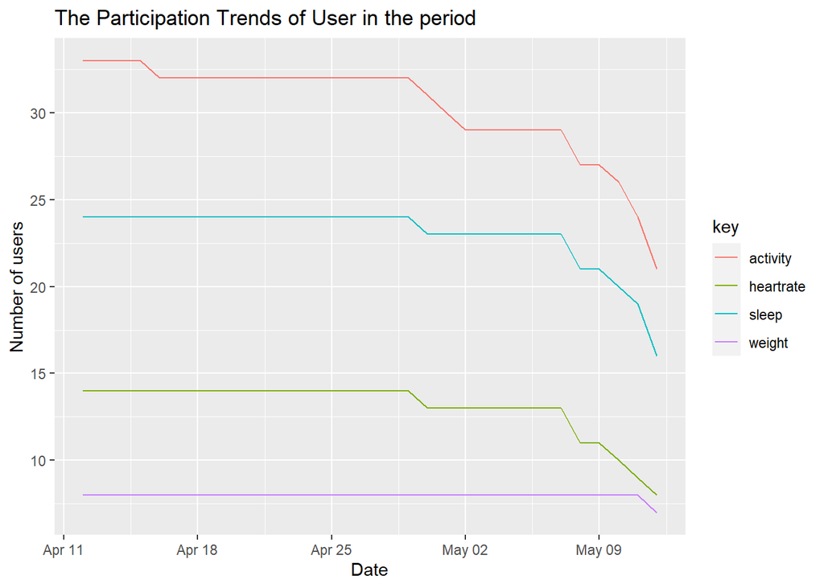

```r
user_act <- activity %>%
  full_join(sleep, by = c("id","date")) %>%
  full_join(heartrate2, by = c("id","date")) %>%
  full_join(weight, by = c("id","date")) %>%
  select(c(1:2)) %>%
  mutate(used_sleep = id %in% sleep$id & date %in% sleep$date,
         used_activity = id %in% activity$id & date %in% activity$date,
         used_heartrate = id %in% heartrate2$id & date %in% heartrate2$date,
         used_weight = id %in% weight$id & date %in% weight$date) %>%
  group_by(date) %>%
  summarise(activity = sum(used_activity), sleep = sum(used_sleep), heartrate = sum(used_heartrate), weight = sum(used_weight)) %>%
  gather(key= "key", value = "value", sleep, activity, heartrate, weight)
ggplot(user_act) + geom_line(mapping = aes(x=date,y=value,color = key)) + ggtitle("The Participation Trends of User in the period") + labs(x="Date", y ="Number of users")
```

```r
summary(user_act$no_id)
```

```
## Length  Class   Mode
##      0   NULL   NULL
```

### Sleep data

```r
# Create sleep id participation
par_sleep_id <-
  group_by(sleep, id) %>%
  summarise(no_day = length(unique(date)))

# Filter for sleep data
sleep_drop_id <- par_sleep_id %>%
  filter(no_day <= 5) %>%
  pull(id)
sleep_drop_id
```

```
## [1] 1644430081 1844505072 1927972279 2320127002 4558609924 6775888955 7007744171
## [8] 8053475328
```

#### The participation of these Users are less than 5 days. Hence they are dropped from the analysis

```r
# Drop low participating users
sleep_new <- filter(sleep, !id %in% sleep_drop_id)
sleep_min_new <- filter(sleep_min, !id %in% sleep_drop_id)
length(unique(sleep_new$id)) # 16 users left
```

```
## [1] 16
```

### Grouping User

#### 1. High intensity: in the 4th quartile of mean intensity of users

#### 2. Moderately intensity: in the 3rd quartile of mean intensity of users

#### 3. Light intensity: in the 2nd quartile of mean intensity of users

#### 4. Low intensity: in the 1st quartile of mean intensity of users

```r
# Create a participation dataframe
par_act_id <-
  group_by(activity, id) %>%
  summarise(no_day = length(unique(date)))
# Filter activity data
act_drop_id <- par_act_id %>%
  filter(no_day <= 5) %>%
  pull(id)
act_drop_id
```

```
## [1] 4057192912
```

#### User with Id 4057192912 only participates for 4 days, thus is dropped from the analysis

```r
# Drop user id
activity_new <- filter(activity, !id %in% act_drop_id)
length(unique(activity_new$id)) # 32 users
```

```
## [1] 32
```

```r
activity_hr_new <- filter(activity_hr, !id %in% act_drop_id)
length(unique(activity_hr_new$id)) # 32 users
```

```
## [1] 32
```

#### After dropping 1 id, the number of unique ids in the activity tables are 32 ids

```r
# Group users based on average intensity per day
intensity_day <- subset(activity_hr_new, select = c(id,date, total_intensity)) %>%
  group_by(id, date) %>%
  summarise(intensity_perday = sum(total_intensity))
intensity_group <- intensity_day %>%
  group_by(id,.add = TRUE) %>%
  summarise(avg_intensity_perday = mean(intensity_perday)) %>%
  mutate(quartile = as.character(as.numeric(cut(avg_intensity_perday,
                                                quantile(avg_intensity_perday,
                                                         probs=c(0, 0.25,0.5, 0.75, 1)),
                                                include.lowest=TRUE))),
         group = case_when(quartile == "1" ~ "Low intensity",
                           quartile == "2" ~ "Light intensity",
                           quartile == "3" ~ "Moderate intensity",
                           quartile == "4" ~ "High intensity")) %>%
  mutate(group = fct_relevel(group, c("Low intensity","Light intensity",
                                      "Moderate intensity", "High intensity")))
head(intensity_group)
```

```
## # A tibble: 6 x 4
##           id avg_intensity_perday quartile group
##        <dbl>                <dbl> <chr>    <fct>
## 1 1503960366                386.  4        High intensity
## 2 1624580081                191.  1        Low intensity
## 3 1644430081                248.  2        Light intensity
## 4 1844505072                118.  1        Low intensity
## 5 1927972279                 44.1 1        Low intensity
## 6 2022484408                404.  4        High intensity
```

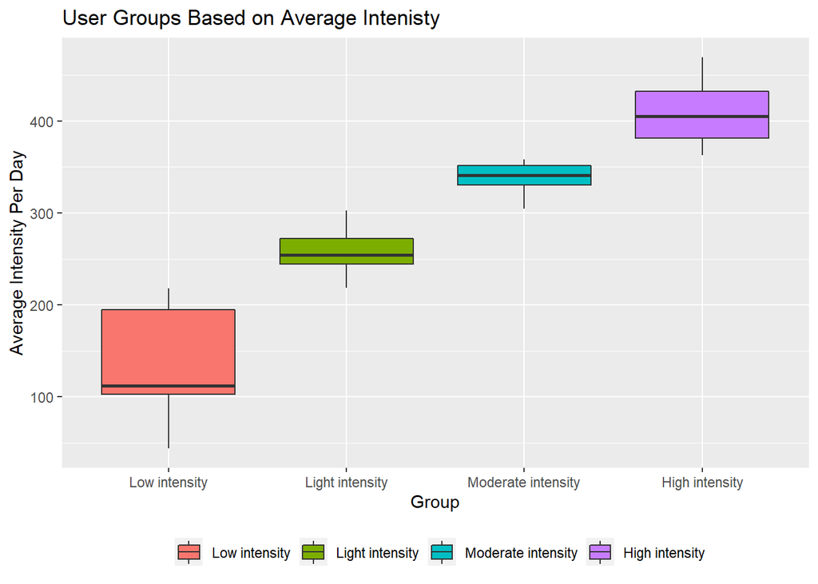

```r
#Plot overview of the 4 groups
ggplot(intensity_group, aes(y=avg_intensity_perday,x=group)) +
  geom_boxplot(aes(fill = group)) + ggtitle("User Groups Based on Average Intenisty") +
  labs(x = "Group", y="Average Intensity Per Day") + theme(legend.title = element_blank(),
                                                           legend.position =  "bottom")
```

### Discussion:

#### 1. Low intensity users tend to have an average intensity per day less than 200

#### 2. Light intensity users tend to have an average intensity per day around 250

#### 3. Moderate intensity users tend to have an average intensity per day near 350

#### 4. High intensity users tend to have an average intensity around 400

```r
# Id list of each user in the groups:
high_int_ids <- intensity_group %>%
  filter(group == "High intensity") %>%
  pull(id)
high_int_ids
```

```
## [1] 1503960366 2022484408 3372868164 3977333714 5577150313 7007744171 8053475328
## [8] 8877689391
```

```r
moderate_int_ids <- intensity_group %>%
  filter(group == "Moderate intensity") %>%
  pull(id)
moderate_int_ids
```

```
## [1] 2347167796 2873212765 4388161847 4558609924 4702921684 6962181067 7086361926
## [8] 8378563200
```

```r
light_int_ids <- intensity_group %>%
  filter(group == "Light intensity") %>%
  pull(id)
light_int_ids
```

```
## [1] 1644430081 2026352035 4319703577 4445114986 5553957443 6117666160 6290855005
## [8] 8583815059
```

```r
low_int_ids <- intensity_group %>%
  filter(group == "Low intensity") %>%
  pull(id)
low_int_ids
```

```
## [1] 1624580081 1844505072 1927972279 2320127002 4020332650 6775888955 8253242879
## [8] 8792009665
```

### Moving on to sleep data, I group users into 2 groups based on average sleep time:

#### 1. Lack of sleep: users with average sleep time less than 7 hours a day

#### 2. Enough sleep: users with average sleep time from 7 hours or more a day

```r
sleep_state <- sleep_new %>%
  group_by(id) %>%
  summarise(asleep = mean(asleep_hr)) %>%
  mutate(state = case_when(asleep < 7 ~ "Lack of sleep",
                           asleep >= 7 ~ "Enough sleep"))
lack_sleep <- sleep_state %>%
  filter(state == "Lack of sleep")
full_sleep <- sleep_state %>%
  filter(state == "Enough sleep")

# Summary of 2 groups
length(unique(lack_sleep$id))
```

```
## [1] 6
```

```r
summary(lack_sleep$asleep)
```

```
##    Min. 1st Qu.  Median    Mean 3rd Qu.    Max.
##   4.894   5.868   6.212   6.128   6.607   6.958
```

```r
length(unique(full_sleep$id))
```

```
## [1] 10
```

```r
summary(full_sleep$asleep)
```

```
##    Min. 1st Qu.  Median    Mean 3rd Qu.    Max.
##   7.200   7.426   7.509   7.643   7.889   8.436
```

#### In the sample, 6 users have lack of sleep and 10 users have average enough sleep.

#### The average hours of “Enough sleep” group is 7.6 hours.

#### The average hours of “Lack of sleep” group is 6.1 hours.

## Answering questions

### Q1: What is the users’ sleep pattern among groups?

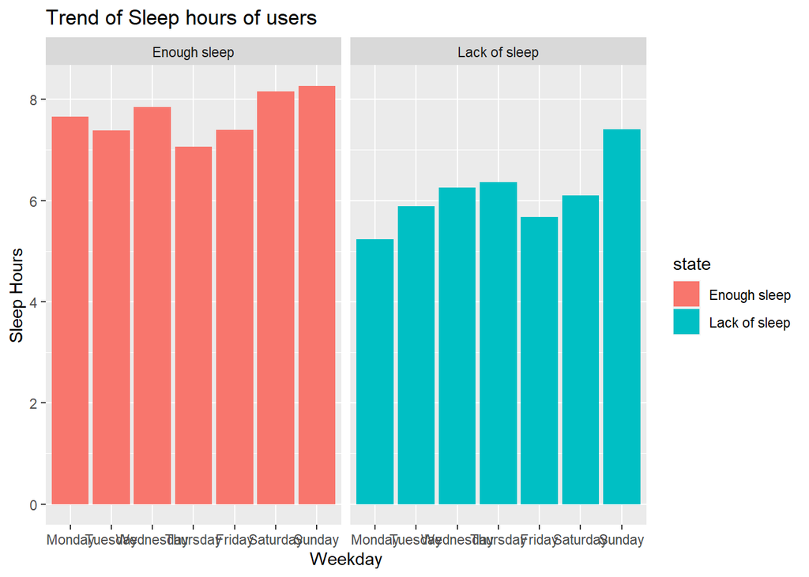

```r
sleep_state %>%
  select(-c(asleep)) %>%
  inner_join(sleep_new, by = "id") %>%
  group_by(weekday,state) %>%
  summarise(asleep_hr = mean(asleep_hr)) %>%
  ggplot(aes(x = weekday, y = asleep_hr, fill = state)) + geom_bar(stat = "identity") + facet_grid(~state) + ggtitle("Trend of Sleep hours of users") + labs(x="Weekday",y="Sleep Hours")
```

### Users categorized in getting enough sleep

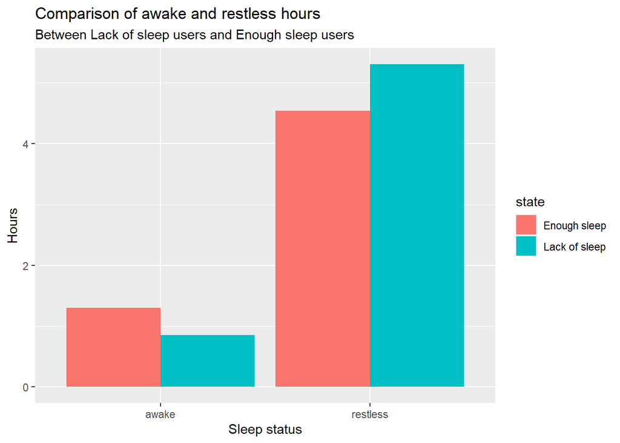

```r
sleep_state %>%
  select(-asleep) %>%
  right_join(sleep_min_new, by = "id") %>%
  group_by(date,state,sleep_status) %>%
  summarise(avg_hour = mean(n())/60) %>%
  filter(sleep_status == "restless"| sleep_status == "awake") %>%
  ggplot() + geom_bar(aes(x=sleep_status, y=avg_hour,fill=state), position = "dodge",stat = "identity") + ggtitle("Comparison of awake and restless hours","Between Lack of sleep users and Enough sleep users") + labs(x="Sleep status", y = "Hours")
```

#### Users with lack of sleep have to go through longer hours of restlessness, which may be part of the reason.

### Q2: What is the tracking feature usage trend?

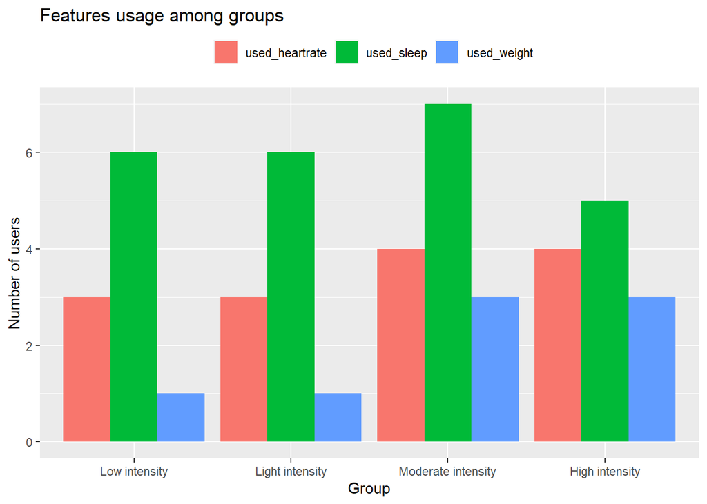

```r
#Obtain feature usage data by groups
usage_by_fea <- intensity_group %>%
  mutate(used_sleep = id%in%sleep$id, used_heartrate = id%in%heartrate2$id, used_weight = id%in%weight$id) %>%
  gather(key = "feature", value = "usage",
         c(used_sleep, used_heartrate, used_weight)) %>% #reshape to long format
  select(-c(avg_intensity_perday, quartile))
#Plot grouped bar chart
ggplot(usage_by_fea, aes(x=group, y=as.numeric(usage), fill = feature)) +
  stat_summary(fun = sum, geom = "bar", position = "dodge") +
  ggtitle("Features usage among groups") +
  labs(x = "Group", y="Number of users") + theme(legend.title = element_blank(),
                                                 legend.position =  "top")
```

#### Most users in every group used sleep tracking feature

#### A portion of user in each groups may be willing to try out other tracking features such as heartrate or weight

#### Moderate intensity and high intensity users tend to measure their weight and heart rate also

#### However, the sample is small and should be investigated with a larger scale to reach a conclusion

## Q3: What is the trend in user daily usage?

### Number of day used by each groups

```r
#Obtain usage data of each user groups
usage_by_day <- intensity_group %>%
  inner_join(activity, by = "id") %>%
  select(c(id,date,group)) %>%
  group_by(group,id) %>%
  summarise(no_day = length(date))
```

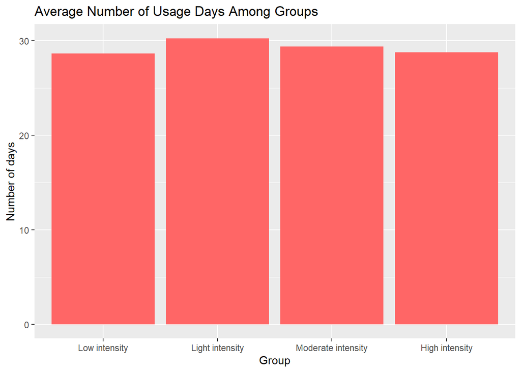

```r
#Plot bar chart
ggplot(usage_by_day, aes(x=group, y = no_day,)) +
  stat_summary(geom = "bar", fun = "mean",fill = "#FF6666") +
  ggtitle("Average Number of Usage Days Among Groups") +
  labs(x = "Group", y="Number of days")
```

## Q4: What is the trend of users’ activity?

### Active and Inactive periods in a day

#### Average daily active minutes

```r
# Obtain active minutes by groups
active_min <- intensity_group %>%
  inner_join(activity , by = "id") %>%
  select(c(id,group,very_active_minutes,fairly_active_minutes)) %>%
  group_by(group, id) %>%
  summarise(very_active_minutes = round(mean(very_active_minutes)),
            fairly_active_minutes = round(mean(fairly_active_minutes))) %>%
  gather(key = "active_type", value = "minutes", very_active_minutes, fairly_active_minutes)
```

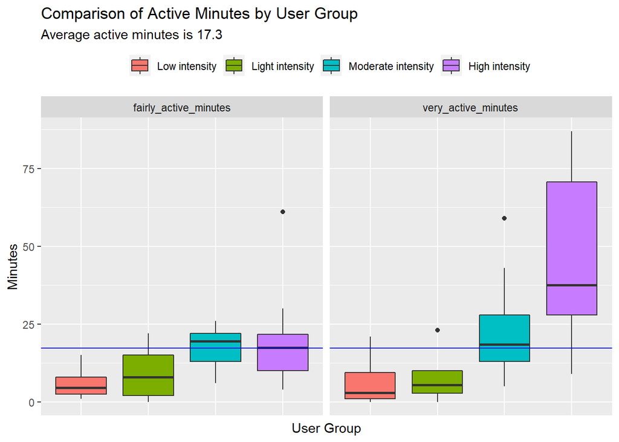

```r
# Plot box plot
ggplot(active_min,aes(x=group, y= minutes, fill = group)) + geom_boxplot() +
  geom_hline(yintercept = mean(active_min$minutes), color = "blue") + xlab("User Group") +
  ylab("Minutes") + ggtitle("Comparison of Active Minutes by User Group","Average active minutes is 17.3") +
  theme(axis.text.x = element_blank(), axis.ticks.x = element_blank(),legend.title = element_blank()) +
  theme(legend.position = "top") + facet_wrap(~active_type)
```

### Discussion:

#### High intensity group mainly performs active sessions in their active periods, while moderate intensity group has more equal amount of very active minutes and fairly active minutes

#### Low intensity and light intensity group have very short active periods throughout their day

### Active minutes throughout days of week

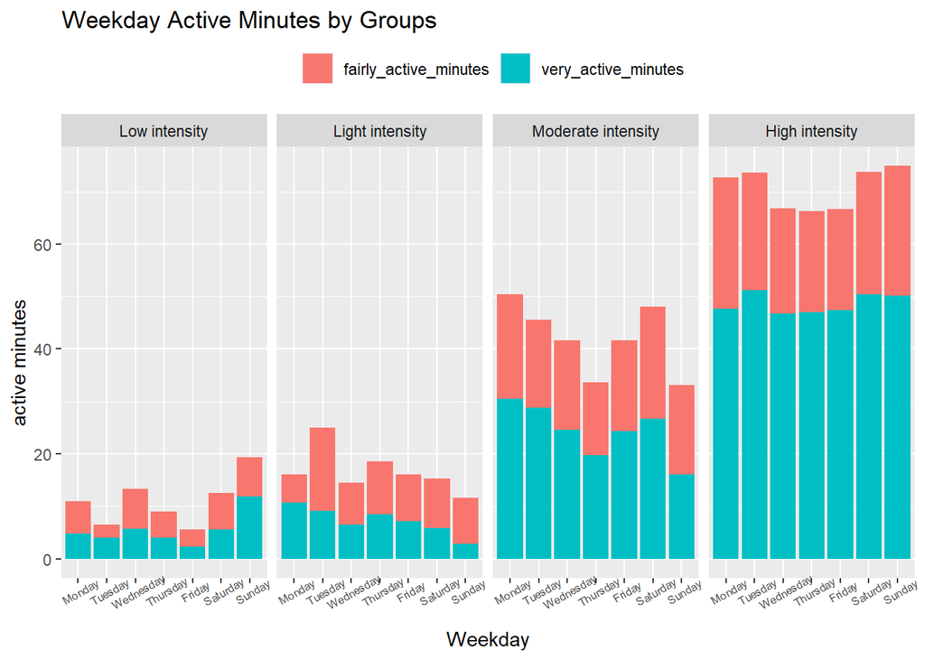

```r
# Obtain active minutes by weekday
active_min_weekday <- intensity_group %>%
  inner_join(activity , by = "id") %>%
  select(c(id,group,date,very_active_minutes,fairly_active_minutes,weekday)) %>%
  gather(key = "active_type", value = "minutes",
         very_active_minutes, fairly_active_minutes)
#Stacked Bar plot
ggplot(active_min_weekday) +
  geom_bar(mapping = aes(x=weekday, y = minutes, fill = active_type),
           stat ="summary", fun="mean", position = "stack") +
  theme(legend.position = "top", legend.title = element_blank(),
        axis.text.x = element_text(angle = 30,size=6)) +
  facet_grid( ~ group) + ggtitle("Weekday Active Minutes by Groups") +
  labs(x="Weekday", y="active minutes")
```

### Lightly active and inactive periods comparison among groups

#### Average lightly and inactive hours

```r
# Obtain inactive and lightly active hours by group
inactive_hour <- intensity_group %>%
  inner_join(activity , by = "id") %>%
  select(c(id,group,lightly_active_minutes,sedentary_minutes)) %>%
  group_by(group, id) %>%
  summarise(lightly_active_hours = round(mean(lightly_active_minutes)/60),
            sedentary_hours = round(mean(sedentary_minutes)/60)) %>%
  gather(key = "active_type", value = "hours", lightly_active_hours, sedentary_hours)
```

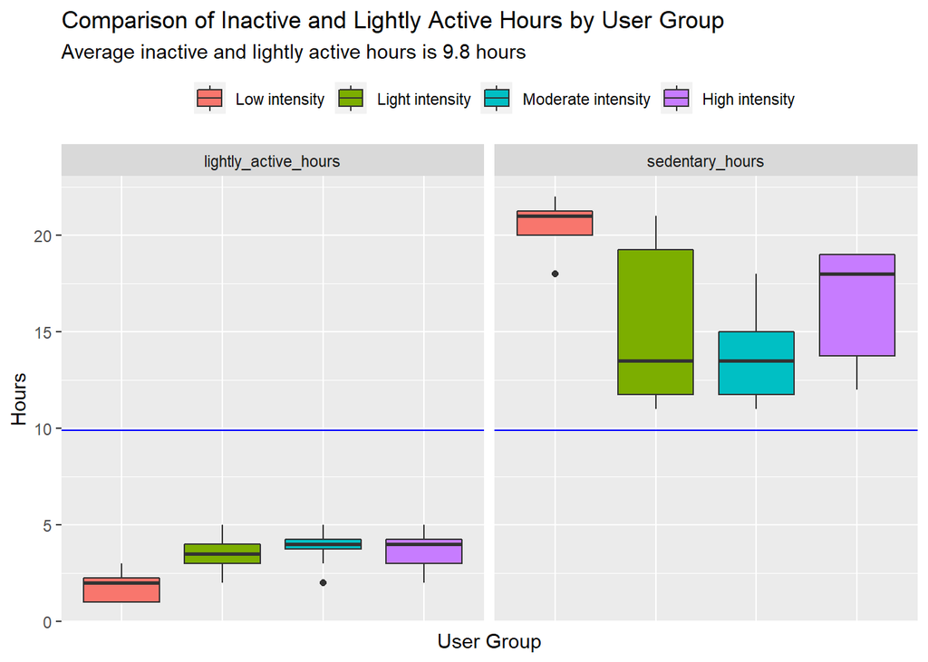

```r
# Boxplot
ggplot(inactive_hour,aes(x=group, y= hours, fill = group)) + geom_boxplot() +
  geom_hline(yintercept = mean(inactive_hour$hours), color = "blue") + xlab("User Group") +
  ylab("Hours") + ggtitle("Comparison of Inactive and Lightly Active Hours by User Group","Average inactive and lightly active hours is 9.8 hours") +
  theme(axis.text.x = element_blank(), axis.ticks.x = element_blank(),legend.title = element_blank()) +
  theme(legend.position = "top") + facet_wrap(~active_type)
```

### Discussion:

#### There is abnormal amount of sedentary hours among low intensity users. This indicate the measured data might be inaccurate due to devices not working, or this group of user had to sit for too long and do not need to move throughout their day. They have very low activity time throughout the days for all types of active activities

### Inactive and lightly hour throughout days of week

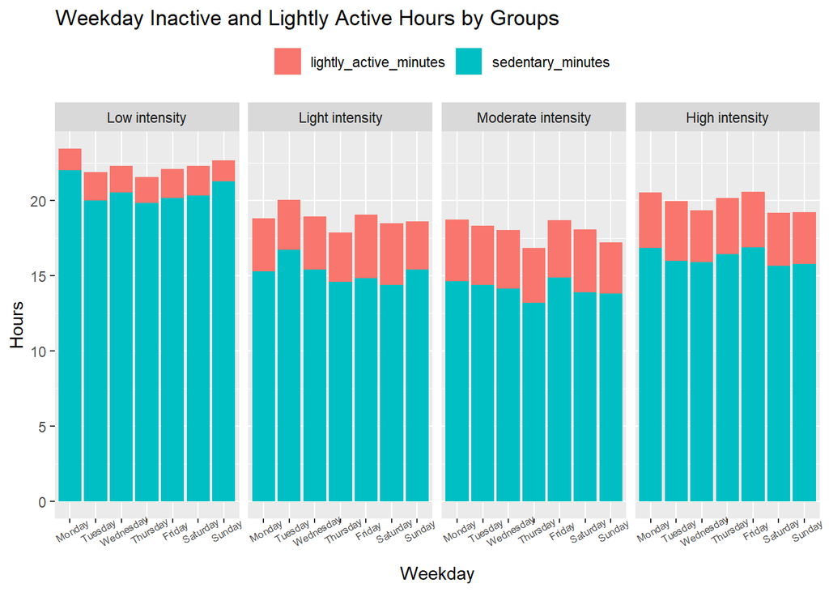

```r
inactive_minutes_weekday <- intensity_group %>%
  inner_join(activity , by = "id") %>%
  select(c(id,group,date,lightly_active_minutes,sedentary_minutes,weekday)) %>%
  gather(key = "active_type", value = "minutes", lightly_active_minutes, sedentary_minutes)
ggplot(inactive_minutes_weekday) +
  geom_bar(mapping = aes(x=weekday, y = minutes/60, fill = active_type),
           stat ="summary", fun="mean", position = "stack") +
  theme(legend.position = "top", legend.title = element_blank(),
        axis.text.x = element_text(angle = 30,size=6)) +
  facet_grid( ~ group) + ggtitle("Weekday Inactive and Lightly Active Hours by Groups") +
  labs(x="Weekday", y="Hours")
```

#### Surprisingly, High intensity group users also have higher sedentary minutes than moderate and light intensity groups. This is probably due to they actively track their activity more frequently than other groups.

#### For others, they may neglect their tracking devices in cases when out of batteries or not tracker not working.

### Intensity among groups

#### Intensity throughout days of week

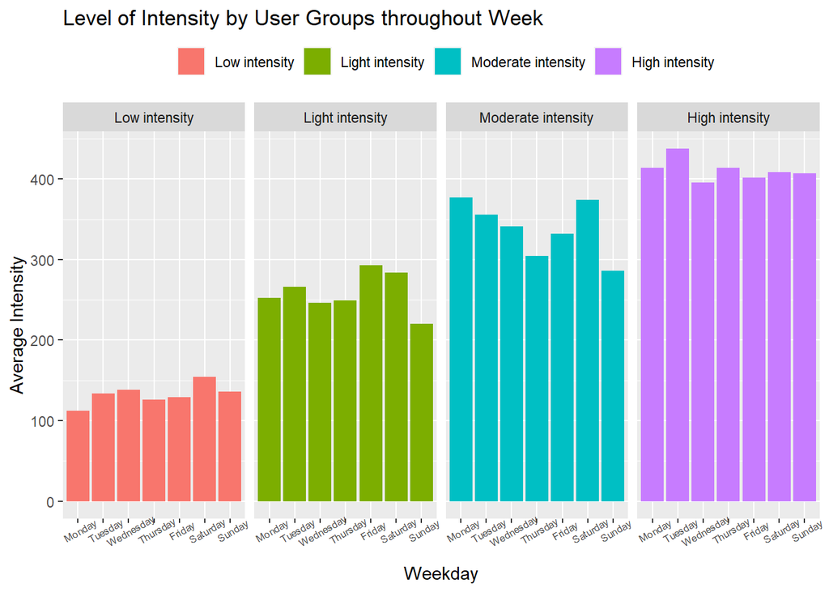

```r
intensity_weekday <- intensity_day %>%
  inner_join(intensity_group, by = 'id') %>%
  mutate(weekday = weekdays(date)) %>%
  mutate(weekday = fct_relevel(weekday,c("Monday","Tuesday","Wednesday",
                                         "Thursday","Friday","Saturday","Sunday"))) %>%
  select(-c(quartile, avg_intensity_perday))
ggplot(intensity_weekday, aes(x = weekday, y = intensity_perday, fill = group)) +
  geom_bar(stat='summary', fun = 'mean',position = "stack") +
  theme(legend.position = "top", legend.title = element_blank(),
        axis.text.x = element_text(angle = 30,size=6)) +
  facet_grid(~group) + ggtitle("Level of Intensity by User Groups throughout Week") +
  labs(x="Weekday",y="Average Intensity")
```

### Intensity throughout the day

#### Light and low intensity group

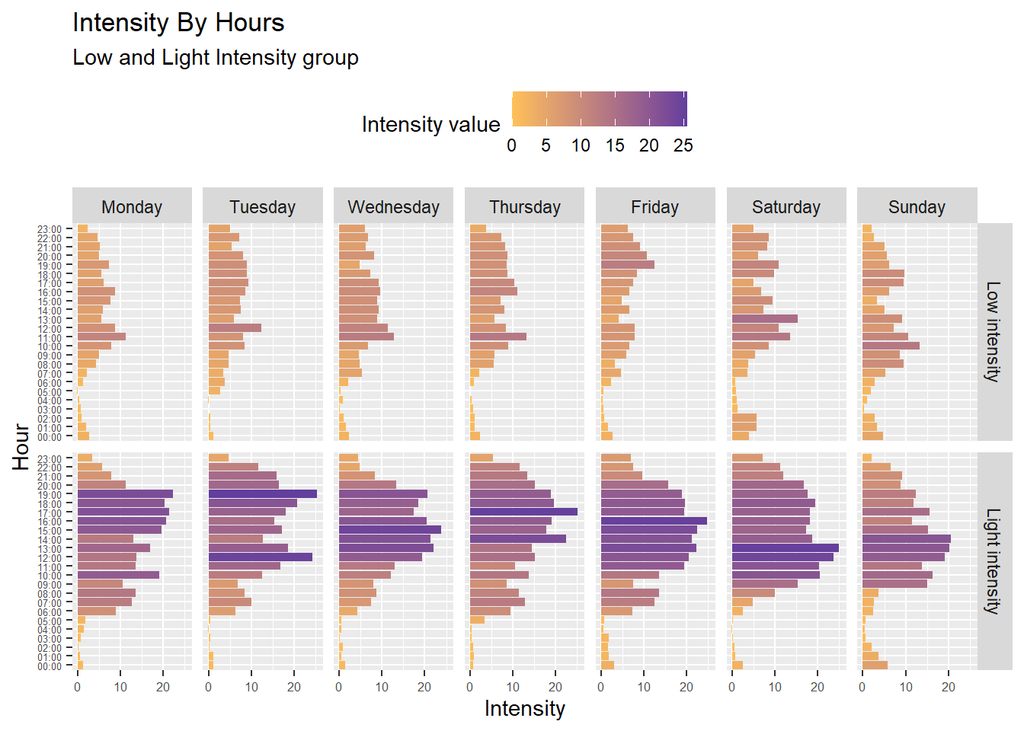

```r
intensity_hr <- activity_hr_new %>%
  select(c(id,date,time,total_intensity,weekday)) %>%
  left_join(intensity_group, by = "id")
intensity_hr %>%
  group_by(group,weekday,time) %>%
  summarise(intensityhr = mean(total_intensity)) %>%
  filter(group == "Light intensity" | group == "Low intensity") %>%
  ggplot(aes(x=time, y=intensityhr, fill = intensityhr))+
  scale_fill_gradient(low = "#FFC058", high = "#623E9D")+
  geom_bar(stat = 'identity', show.legend = TRUE) +
  coord_flip() +
  ggtitle("Intensity By Hours", "Low and Light Intensity group") +
  xlab("Hour") + ylab("Intensity") + labs(fill = "Intensity value") +
  theme(axis.text.x = element_text(size=6), axis.text.y = element_text(size=5))+
  theme(legend.position = "top")+
  facet_grid(group~weekday)
```

### Discussion

#### Low intensity group: intensity throughout week is consistent, which tend to the value peaks at noon time

#### Light intensity group: on weekday, they are more active in the afternoon and evening, while on weekend, their most active period is at noon

### Moderate and High intensity groups

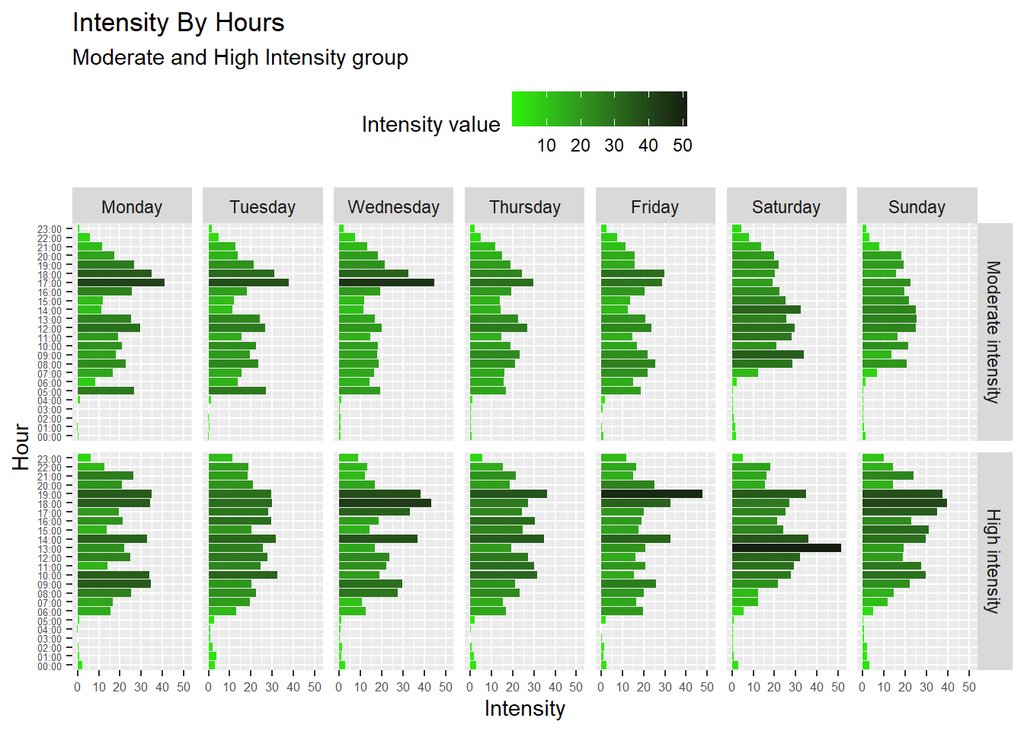

```r
intensity_hr %>%
  group_by(group,weekday,time) %>%
  summarise(intensityhr = mean(total_intensity)) %>%
  filter(group == "Moderate intensity" | group == "High intensity") %>%
  ggplot(aes(x=time, y=intensityhr, fill = intensityhr))+
  scale_fill_gradient(low = "#2AF203", high = "#151E11")+
  geom_bar(stat = 'identity', show.legend = TRUE) +
  coord_flip() +
  ggtitle("Intensity By Hours", "Moderate and High Intensity group") +
  xlab("Hour") + ylab("Intensity") + labs(fill = "Intensity value") +
  theme(axis.text.x = element_text(size=6), axis.text.y = element_text(size=5))+
  theme(legend.position = "top")+
  facet_grid(group~weekday)
```

### Discuss:

#### These 2 groups tend to have certain very active hour each day throughout the week

#### However, for moderate intensity group, there are different active periods between weekend and weekdays, in weekend they are more active at noon while on weekdays, their peak hours are the evening

#### The peak active hours are from 17:00 to 19:00

## 7. Recommendation

### Based on the findings in the analysis, I provide the following recommendations for the Bellabeat App and Membership Program:

#### 1. Targetting: Because user stickiness to use the tracking features among groups are not different, it is recommended that the user acquisition for the app should be targetted widely, including both people with already healthy fitness habits and people with high inactivity. However, the approach of the app should be different for each groups.

#### 2. Tailoring Message:

#### a) High intensity group: The app should aim to maintain their current good habit by acting as a reliable reminder for their daily workout period, and promote a wide variety of intense workout.

#### b) Low intensity group: The app should aim to encourage these users to take small steps in their workout and exercise by acting as an encouraging friend. Eg. Alerting long inactivity period and encourage them to take a brisk walk or stretch their body.

#### c) Moderate and light intensity groups: The app should aim to give them a push to help them become a high intensity user by acting as an encouraging coach. Eg. encourage them to increase the workout periods for 5 minutes that day or feature short intense exercises for them to add to their periods.

#### d)For users with lack of sleep, the app should personalized feature posts for them improve sleep quality such as lowering stress and mindfulness habits.

#### e)Because some users may only use 1 or 2 tracking features, the app should have posts emphasizing the benefits of tracking multiple areas of their health habit to improving overall wellbeing.